# Capital Cities (Urban Mobility)

# 1 Capital Cities (Urban Mobility)

## 1.1 Sample Populations

This section covers the descriptive statistics of the four sample populations.

### 1.1.1 Dhaka 2009

The data were captured on October 1-2, 2009 with a sample size of 42,111 people. The personal data occupies 3.5 Mb of memory.

Data set description:

```r
describe(dhk09.person)
```

```
## dhk09.person
##
##  6  Variables      42111  Observations
## ---------------------------------------------------------------------------
## pid
##       n missing  unique
##   42111       0   42111
##
## lowest : 1     2     3     4     5
## highest: 47486 47489 47491 47492 47493
## ---------------------------------------------------------------------------
## sex
##       n missing  unique
##   42111       0       2
##
## Male (22541, 54%), Female (19570, 46%)
## ---------------------------------------------------------------------------
## age
##       n missing  unique
##   42111       0      18
##
##           [0, 5[ [5, 10[ [10, 15[ [15, 20[ [20, 25[ [25, 30[ [30, 35[
## Frequency    319    3555     4567     4236     4949     5161     4133
## %              1       8       11       10       12       12       10
##           [35, 40[ [40, 45[ [45, 50[ [50, 55[ [55, 60[ [60, 65[ [65, 70[
## Frequency     4031     3138     2693     2123     1363      972      476
## %               10        7        6        5        3        2        1
##           [70, 75[ [75, 80[ [80, 85[ [85, Inf[
## Frequency      269       97       21         8
## %                1        0        0         0
## ---------------------------------------------------------------------------
## occup
##       n missing  unique
##   42111       0       9
##
## Unknown (865, 2%), Government service (1925, 5%)
## Private service (6901, 16%)
## Business (6468, 15%), Unemployed (841, 2%)
## Student (13861, 33%), Housewife (10571, 25%)
## Agriculture, farming (31, 0%)
## Others (specify) (648, 2%)
## ---------------------------------------------------------------------------
## occupc
##       n missing  unique
##   42111       0       6
##
## Blue-collar (31, 0%), White-collar (15294, 36%)
## Student (13861, 33%)
## Housewife, househusband (10571, 25%)
## Unemployed, retired (841, 2%)
## Other, unknown (1513, 4%)
## ---------------------------------------------------------------------------
## dist
##       n missing  unique    Mean     .05     .10     .25     .50     .75
##   42111       0   41963   11584    1250    1893    3713    7839   15293
##     .90     .95
##   25342   33859
##
## lowest :      0.00     14.97     30.46     55.55     61.39
## highest: 126406.08 126643.55 135625.47 152718.42 182414.31
## ---------------------------------------------------------------------------
```

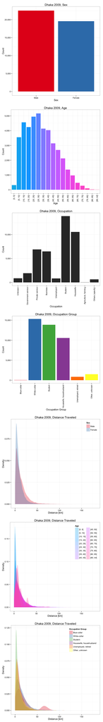

### 1.1.2 Hanoi 2004

The data were captured on October 1-2, 2004 with a sample size of 34,846 people. The personal data occupies 2.8 Mb of memory.

Data set description:

```r
describe(hni04.person)
```

```
## hni04.person
##
##  6  Variables      34846  Observations
## ---------------------------------------------------------------------------
## pid
##       n missing  unique
##   34846       0   34846
##
## lowest : 2     3     4     5     6
## highest: 47486 47489 47491 47492 47493
## ---------------------------------------------------------------------------
## sex
##       n missing  unique
##   34846       0       2
##
## Male (17343, 50%), Female (17503, 50%)
## ---------------------------------------------------------------------------
## age
##       n missing  unique
##   34846       0      18
##
##           [0, 5[ [5, 10[ [10, 15[ [15, 20[ [20, 25[ [25, 30[ [30, 35[
## Frequency      1    1033     2265     2594     3521     3507     2957
## %              0       3        7        7       10       10        8
##           [35, 40[ [40, 45[ [45, 50[ [50, 55[ [55, 60[ [60, 65[ [65, 70[
## Frequency     1943     2285     2892     2546     2340     2122     1926
## %                6        7        8        7        7        6        6
##           [70, 75[ [75, 80[ [80, 85[ [85, Inf[
## Frequency     1360      803      433       318
## %                4        2        1         1
## ---------------------------------------------------------------------------
## occup
##       n missing  unique
##   34846       0      18
##
## [Undocumented_1] (7, 0%)
## Leader of branches, units (553, 2%)
## Professional (1417, 4%)
## Technical and associate professional (1493, 4%)
## Clerical worker (5250, 15%)
```

[output cut: 16 more lines]

```
## Blue-collar (5130, 15%), White-collar (9291, 27%)
## Student (7287, 21%)
## Housewife, househusband (1012, 3%)
## Unemployed, retired (9642, 28%)
## Other, unknown (2484, 7%)
## ---------------------------------------------------------------------------
## dist
##       n missing  unique    Mean     .05     .10     .25     .50     .75
##   34846       0   34754   11522    1289    1938    3774    7880   15211
##     .90     .95
##   24994   33378
##
## lowest :      0.00     14.97     30.46     55.55     61.39
## highest: 126406.08 126643.55 135625.47 152718.42 182414.31
## ---------------------------------------------------------------------------
```

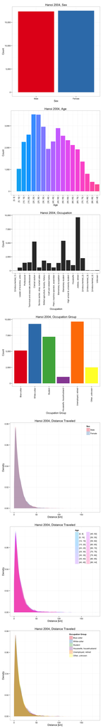

### 1.1.3 Jakarta 2002

The data were captured on October 1-2, 2002 with a sample size of 36,713 people. The personal data occupies 2.9 Mb of memory.

Data set description:

```r
describe(jkt02.person)
```

```
## jkt02.person
##
##  6  Variables      36713  Observations
## ---------------------------------------------------------------------------
## pid
##       n missing  unique
##   36713       0   36713
##
## lowest : 1     2     3     4     6
## highest: 47486 47489 47491 47492 47493
## ---------------------------------------------------------------------------
## sex
##       n missing  unique
##   36713       0       2
##
## Male (19196, 52%), Female (17517, 48%)
## ---------------------------------------------------------------------------
## age
##       n missing  unique
##   36713       0      17
##
##           [5, 10[ [10, 15[ [15, 20[ [20, 25[ [25, 30[ [30, 35[ [35, 40[
## Frequency    2964     3489     4190     4502     5135     3671     3400
## %               8       10       11       12       14       10        9
##           [40, 45[ [45, 50[ [50, 55[ [55, 60[ [60, 65[ [65, 70[ [70, 75[
## Frequency     2722     2431     1769      732      783      532      243
## %                7        7        5        2        2        1        1
##           [75, 80[ [80, 85[ [85, Inf[
## Frequency       45       58        47
## %                0        0         0
## ---------------------------------------------------------------------------
## occup
##       n missing  unique
##   36713       0      18
##
## Unknown (20723, 56%)
## Professor, manager, director, etc. (940, 3%)
## Industry owner, retail owner, etc. (1110, 3%)
## Engineer, doctor, accountant, pilot, etc. (1340, 4%)
## Teacher, lecturer (940, 3%)
```

[output cut: 12 more lines]

```
##       n missing  unique
##   36713       0       4
##
## Blue-collar (4913, 13%), White-collar (9441, 26%)
## Student (940, 3%), Other, unknown (21419, 58%)
## ---------------------------------------------------------------------------
## dist
##       n missing  unique    Mean     .05     .10     .25     .50     .75
##   36713       0   36604   11592    1262    1904    3717    7841   15313
##     .90     .95
##   25394   34016
##
## lowest :      0.00     14.97     30.46     55.55     61.39
## highest: 124771.38 126406.08 126643.55 135625.47 182414.31
## ---------------------------------------------------------------------------
```

[figure not shown]

### 1.1.4 Metro Manila 1996

```
## [1] TRUE
```

```
## [1] TRUE
```

```
## [1] TRUE
```

```
## [1] TRUE
```

The data were captured on October 1-2, 1996 with a sample size of 189,335 people. The personal data occupies 15.2 Mb of memory.

Data set description:

```r
describe(mnl96.person)
```

```
## mnl96.person
##
##  6  Variables      189335  Observations
## ---------------------------------------------------------------------------
## pid
##       n missing  unique
##  189335       0  189335
##
## lowest : 1      2      3      4      5
## highest: 203517 203518 203519 203520 203521
## ---------------------------------------------------------------------------
## sex
##       n missing  unique
##  189335       0       2
##
## Male (87768, 46%), Female (101567, 54%)
## ---------------------------------------------------------------------------
## age
##       n missing  unique
##  189335       0      18
##
##           [0, 5[ [5, 10[ [10, 15[ [15, 20[ [20, 25[ [25, 30[ [30, 35[
## Frequency   2617   22125    21710    22320    20383    18998    17071
## %              1      12       11       12       11       10        9
##           [35, 40[ [40, 45[ [45, 50[ [50, 55[ [55, 60[ [60, 65[ [65, 70[
## Frequency    15662    13426    11169     8274     5951     4405     2943
## %                8        7        6        4        3        2        2
##           [70, 75[ [75, 80[ [80, 85[ [85, Inf[
## Frequency     1138      597      331       215
## %                1        0        0         0
## ---------------------------------------------------------------------------
## occup
##       n missing  unique
##  189335       0      14
##
##           Executive Professional Technician Clerical Service Farmer Trade
## Frequency     18292         5933       3661     5065   10885   1309  5608
## %                10            3          2        3       6      1     3
##           Operator Laborer Pupil Student Housewife Jobless Others
## Frequency     7034   13639 35029   25624     30402   19559   7295
## %                4       7    19      14        16      10      4
## ---------------------------------------------------------------------------
## occupc
##       n missing  unique
##  189335       0       6
##
## Blue-collar (18609, 10%)
## White-collar (52817, 28%), Student (60653, 32%)
## Housewife, househusband (30402, 16%)
## Unemployed, retired (19559, 10%)
## Other, unknown (7295, 4%)
## ---------------------------------------------------------------------------
##
## Variables with all observations missing:
##
## [1] dist
```

[figure not shown]

### 1.1.5 Comparison Across Cities

#### 1.1.5.1 Sex

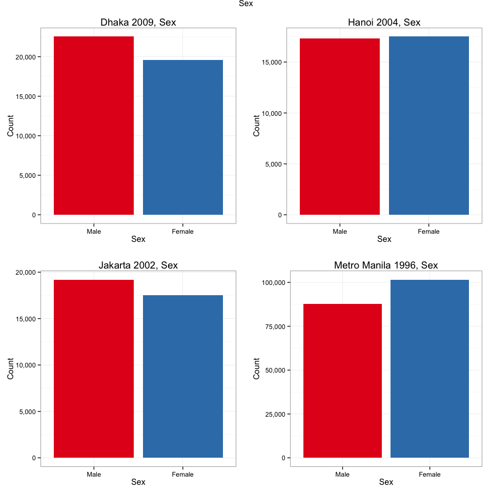

#### 1.1.5.2 Age

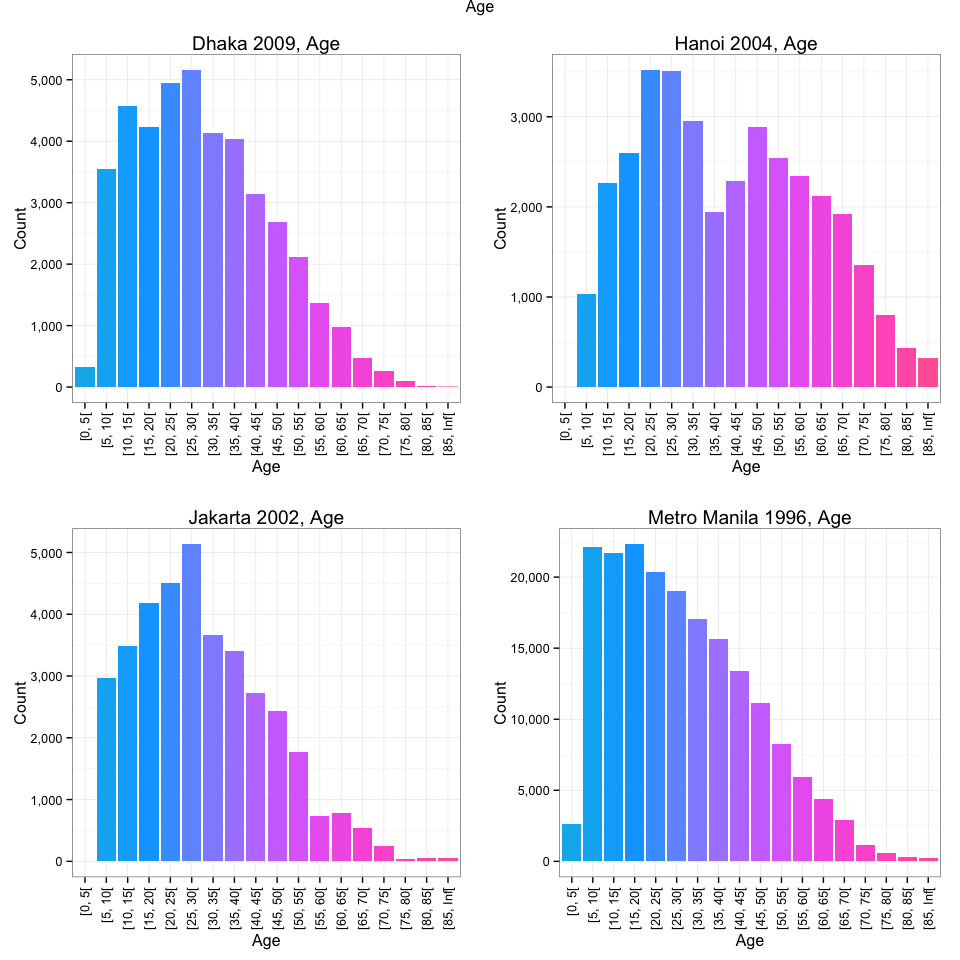

#### 1.1.5.3 Occupation

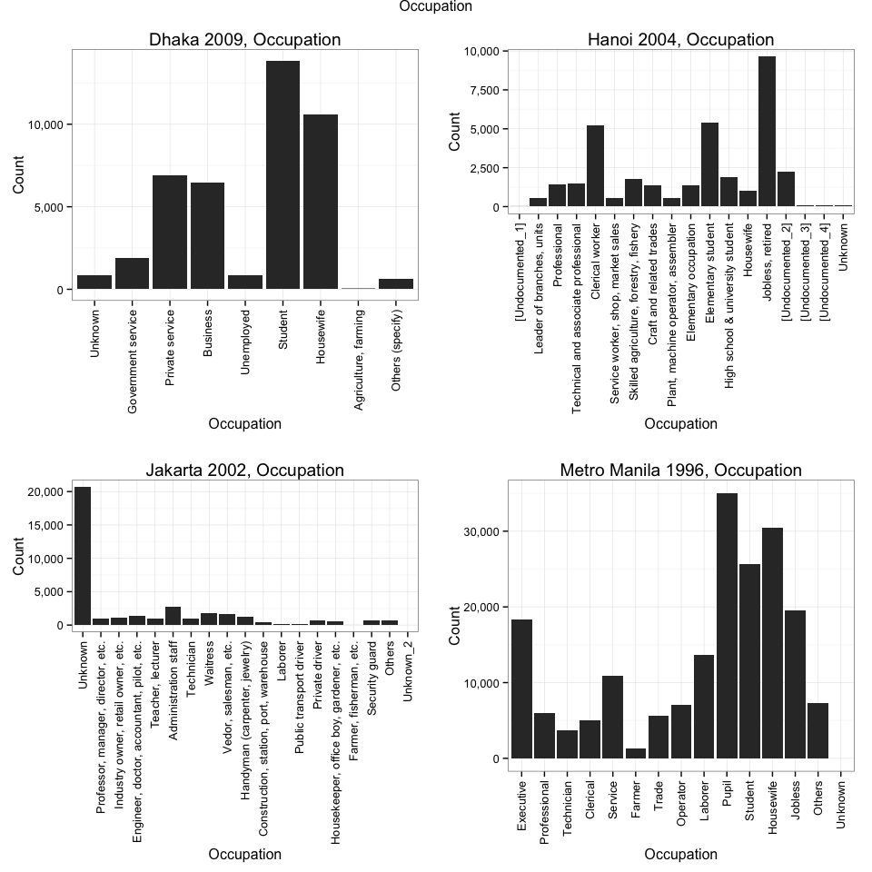

#### 1.1.5.4 Occupation Group

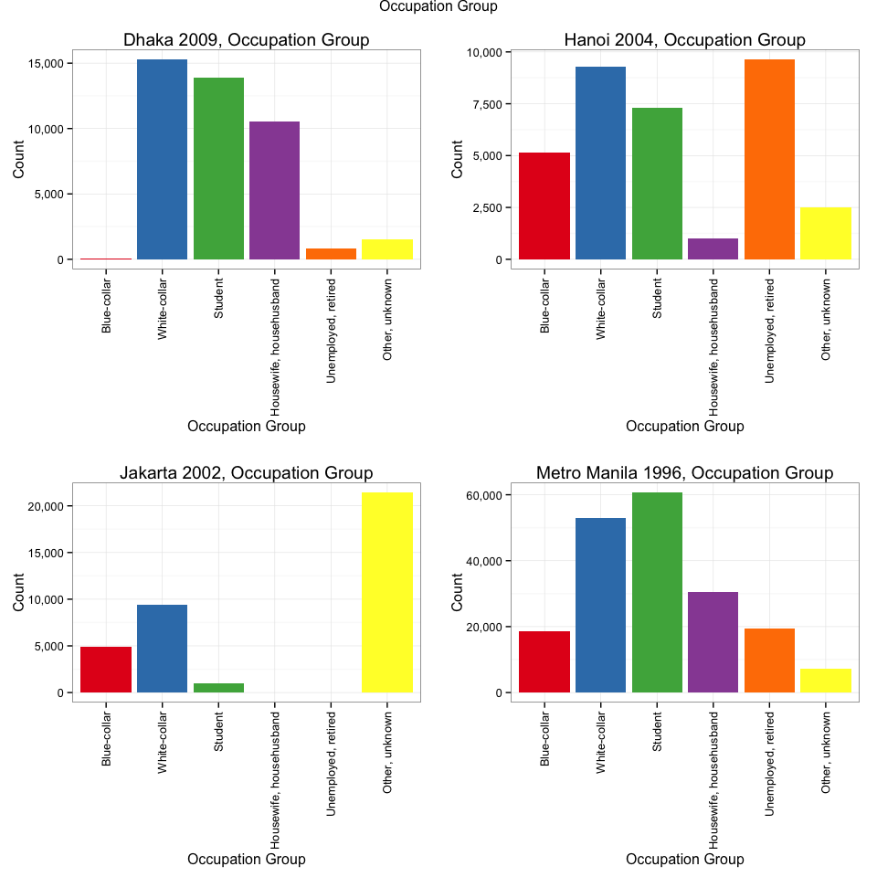

#### 1.1.5.5 Distance Traveled

[figure not shown]

[figure not shown]

[figure not shown]

## 1.2 Sample Trips

### 1.2.1 Dhaka 2009

The 42,111 people in the sample made a total of 105,121 non-stationary trips. The trip data occupies 5.9 Mb of memory.

Data set description:

```r
describe(dhk09.trip)
```

```
## dhk09.trip
##
##  6  Variables      105121  Observations
## ---------------------------------------------------------------------------
## pid
##       n missing  unique
##  105121       0   42098
##
## lowest : 1     2     3     4     5
## highest: 47486 47489 47491 47492 47493
## ---------------------------------------------------------------------------
## tno
##       n missing  unique
##  105121       0      18
##
##           1     2   3     4   5     6   7    8  9   10 11  12 13 14 15 16
## Frequency 2 42096 356 41689 184 10873 202 7850 63 1311 27 374  7 58  2 21
## %         0    40   0    40   0    10   0    7  0    1  0   0  0  0  0  0
##           18 20
## Frequency  4  2
## %          0  0
## ---------------------------------------------------------------------------
## activity
##       n missing  unique
##  105121       0       7
##
##            Home  Work Education Shopping Social, recreation Errand
## Frequency 45257 23676     13455     6455               6775   1851
## %            43    23        13        6                  6      2
##           Other, unknown
## Frequency           7652
## %                      7
## ---------------------------------------------------------------------------
## dist
##       n missing  unique    Mean     .05     .10     .25     .50     .75
##  105121       0  103368    4641   500.1   765.3  1511.2  3064.1  6039.5
##     .90     .95
## 10120.5 13780.7
##
## lowest :     4.232     5.451     7.485     7.485     8.853
```

[output cut: 13 more lines]

```
## highest: 2009-10-01 23:20:00 2009-10-01 23:25:00 2009-10-01 23:29:00 2009-10-01 23:35:00 2009-10-01 23:39:00
## ---------------------------------------------------------------------------
## pdate_e
##                   n             missing              unique
##              105121                   0                1069
##                Mean                 .05                 .10
## 2009-10-01 12:43:30 2009-10-01 06:30:00 2009-10-01 07:30:00
##                 .25                 .50                 .75
## 2009-10-01 09:00:00 2009-10-01 12:06:00 2009-10-01 16:28:00
##                 .90                 .95
## 2009-10-01 19:27:00 2009-10-01 20:39:00
##
## lowest : 2009-10-01 01:00:00 2009-10-01 01:04:00 2009-10-01 01:05:00 2009-10-01 01:07:00 2009-10-01 01:09:00
## highest: 2009-10-01 23:47:00 2009-10-01 23:49:00 2009-10-01 23:50:00 2009-10-01 23:54:00 2009-10-02 06:00:00
## ---------------------------------------------------------------------------
```

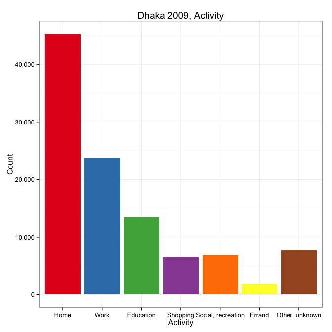

### 1.2.2 Hanoi 2004

The 34,846 people in the sample made a total of 122,530 non-stationary trips. The trip data occupies 6.5 Mb of memory.

Data set description:

```r
describe(hni04.trip)
```

```
## hni04.trip
##
##  6  Variables      122530  Observations
## ---------------------------------------------------------------------------
## pid
##       n missing  unique
##  122530       0   42908
##
## lowest : 2     4     6     7     8
## highest: 75912 75913 75914 75915 75918
## ---------------------------------------------------------------------------
## tno
##       n missing  unique
##  122530       0      28
##
## lowest : 1  2  3  4  5 , highest: 24 25 26 27 28
## ---------------------------------------------------------------------------
## activity
##       n missing  unique
##  122502      28       7
##
##            Home  Work Education Shopping Social, recreation Errand
## Frequency 56799 27966     13628     8065               4903  11011
## %            46    23        11        7                  4      9
##           Other, unknown
## Frequency            130
## %                      0
## ---------------------------------------------------------------------------
## dist
##       n missing  unique    Mean     .05     .10     .25     .50     .75
##  122530       0   76956    3908   327.2   540.9  1160.5  2609.3  5098.8
##     .90     .95
##  8570.0 11436.6
##
## lowest :     9.199     9.202     9.207     9.220     9.221
## highest: 49427.900 51578.803 59683.450 82004.481 97926.501
## ---------------------------------------------------------------------------
## pdate_s
##                   n             missing              unique
##              122530                   0                 434
```

[output cut: 8 more lines]

```
## highest: 2004-10-01 23:20:00 2004-10-01 23:25:00 2004-10-01 23:30:00 2004-10-01 23:40:00 2004-10-01 23:45:00
## ---------------------------------------------------------------------------
## pdate_e
##                   n             missing              unique
##              122530                   0                 788
##                Mean                 .05                 .10
## 2004-10-01 12:11:44 2004-10-01 06:40:00 2004-10-01 07:00:00
##                 .25                 .50                 .75
## 2004-10-01 07:45:00 2004-10-01 11:40:00 2004-10-01 16:50:00
##                 .90                 .95
## 2004-10-01 18:10:00 2004-10-01 19:45:00
##
## lowest : 2004-10-01 00:05:00 2004-10-01 00:15:00 2004-10-01 01:10:00 2004-10-01 01:15:00 2004-10-01 01:20:00
## highest: 2004-10-01 23:40:00 2004-10-01 23:45:00 2004-10-01 23:50:00 2004-10-01 23:55:00 2004-10-01 23:59:00
## ---------------------------------------------------------------------------
```

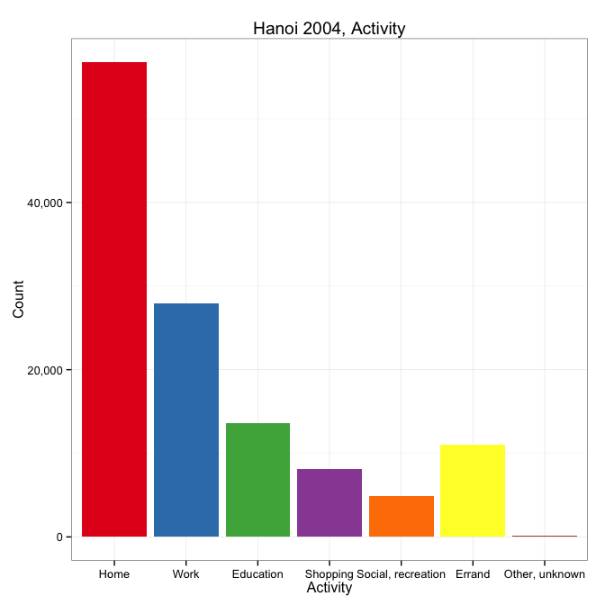

### 1.2.3 Jakarta 2002

The 36,713 people in the sample made a total of 746,149 non-stationary trips. The trip data occupies 41.5 Mb of memory.

Data set description:

```r
describe(jkt02.trip)
```

```
## jkt02.trip
##
##  6  Variables      746149  Observations
## ---------------------------------------------------------------------------
## pid
##       n missing  unique
##  746149       0  297042
##
## lowest : 1      2      3      4      6
## highest: 416994 417004 417009 417027 417029
## ---------------------------------------------------------------------------
## tno
##       n missing  unique
##  746149       0      26
##
## lowest : 1  2  3  4  5 , highest: 24 26 28 30 32
## ---------------------------------------------------------------------------
## activity
##       n missing  unique
##  746149       0       6
##
##             Home   Work Education Shopping Errand Other, unknown
## Frequency 334970 152190    107652    53452  77765          20120
## %             45     20        14        7     10              3
## ---------------------------------------------------------------------------
## dist
##       n missing  unique    Mean     .05     .10     .25     .50     .75
##  746149       0  714595   14836   781.8  1328.5  3619.3 11679.2 22135.0
##     .90     .95
## 32850.5 41483.7
##
## lowest : 1.827e+00 2.715e+00 2.891e+00 2.895e+00 2.901e+00
## highest: 1.123e+05 1.134e+05 1.146e+05 1.152e+05 1.240e+05
## ---------------------------------------------------------------------------
## pdate_s
##                   n             missing              unique
##              746149                   0                 984
##                Mean                 .05                 .10
## 2002-10-01 11:42:47 2002-10-01 06:00:00 2002-10-01 06:30:00
##                 .25                 .50                 .75
## 2002-10-01 07:15:00 2002-10-01 11:50:00 2002-10-01 16:00:00
##                 .90                 .95
## 2002-10-01 17:50:00 2002-10-01 19:05:00
##
## lowest : 2002-10-01 00:00:00 2002-10-01 00:08:00 2002-10-01 00:09:00 2002-10-01 00:30:00 2002-10-01 01:00:00
## highest: 2002-10-01 23:40:00 2002-10-01 23:45:00 2002-10-01 23:50:00 2002-10-01 23:55:00 2002-10-01 23:57:00
## ---------------------------------------------------------------------------
## pdate_e
##                   n             missing              unique
##              746149                   0                1206
##                Mean                 .05                 .10
## 2002-10-01 12:13:39 2002-10-01 06:40:00 2002-10-01 06:50:00
##                 .25                 .50                 .75
## 2002-10-01 08:00:00 2002-10-01 12:05:00 2002-10-01 16:15:00
##                 .90                 .95
## 2002-10-01 18:30:00 2002-10-01 19:58:00
##
## lowest : 2002-10-01 00:02:00 2002-10-01 00:05:00 2002-10-01 00:10:00 2002-10-01 00:15:00 2002-10-01 00:20:00
## highest: 2002-10-01 23:50:00 2002-10-01 23:54:00 2002-10-01 23:55:00 2002-10-01 23:58:00 2002-10-01 23:59:00
## ---------------------------------------------------------------------------
```

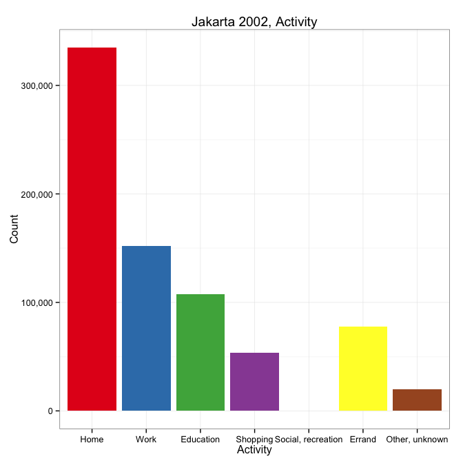

### 1.2.4 Metro Manila 1996

```
## [1] TRUE
```

```
## [1] TRUE
```

```
## [1] TRUE
```

```
## [1] TRUE
```

The 189,335 people in the sample made a total of 324,312 non-stationary trips. The trip data occupies 13.9 Mb of memory.

Data set description:

```r
describe(mnl96.trip)
```

```
## mnl96.trip
##
##  4  Variables      324312  Observations
## ---------------------------------------------------------------------------
## pid
##       n missing  unique
##  324312       0  144786
##
## lowest : 1      3      4      5      6
## highest: 203517 203518 203519 203520 203521
## ---------------------------------------------------------------------------
## tno
##       n missing  unique
##  324312       0      38
##
## lowest : 1  2  3  4  5 , highest: 34 35 36 37 39
## ---------------------------------------------------------------------------
## activity
##       n missing  unique
##  324312       0       7
##
##             Home  Work Education Shopping Social, recreation Errand
## Frequency 152507 69545     57706    21903              12531   7397
## %             47    21        18        7                  4      2
##           Other, unknown
## Frequency           2723
## %                      1
## ---------------------------------------------------------------------------
##
## Variables with all observations missing:
##
## [1] dist
```

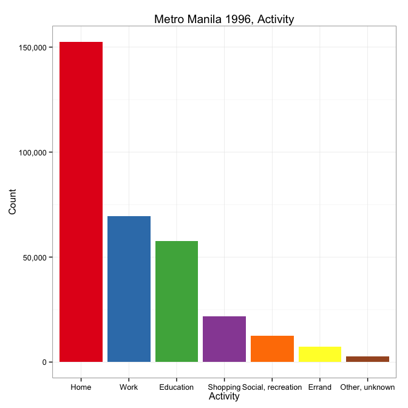

### 1.2.5 Comparison Across Cities

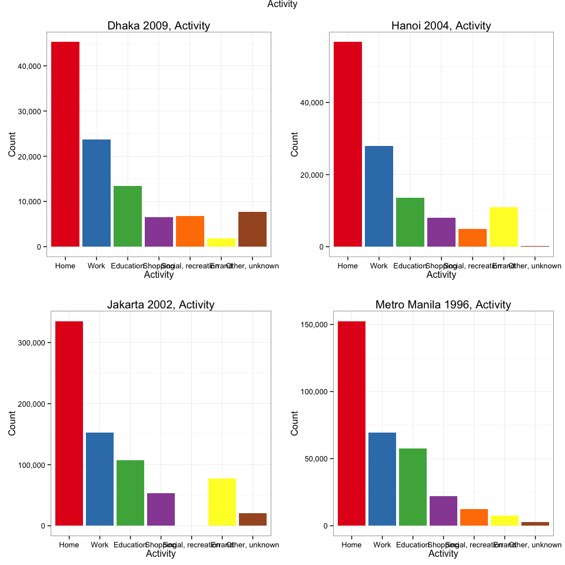

## 1.3 Sample Subtrips

### 1.3.1 Dhaka 2009

The 42,111 people in the sample made a total of 314,029 subtrips. 46.7% of these are actually stationarity events, which reduces the true number of subtrips to 167,354. The subtrip data occupies 5.9 Mb of memory.

Data set description:

```r
describe(dhk09.subtrip)
```

```
## dhk09.subtrip
##
##  9  Variables      167354  Observations
## ---------------------------------------------------------------------------
## pid
##       n missing  unique
##  167354       0   42098
##
## lowest : 1     2     3     4     5
## highest: 47486 47489 47491 47492 47493
## ---------------------------------------------------------------------------
## tno
##       n missing  unique
##  167354       0      18
##
##           1     2   3     4   5     6   7     8   9   10 11  12 13 14 15
## Frequency 6 68427 586 64701 254 18095 274 12311 101 1913 42 534  8 67  2
## %         0    41   0    39   0    11   0     7   0    1  0   0  0  0  0
##           16 18 20
## Frequency 26  5  2
## %          0  0  0
## ---------------------------------------------------------------------------
## sno
##       n missing  unique
##  167354       0       5
##
##                1     2     3    4   5
## Frequency 105121 44055 16012 2009 157
## %             63    26    10    1   0
## ---------------------------------------------------------------------------
## tmode
##       n missing  unique
##  167354       0      18
##
## Walking (65527, 39%), Bicycle (410, 0%)
## Motorcycle (1529, 1%), CNG, mishuk (5684, 3%)
## Auto temp (2163, 1%), Car (5348, 3%)
## Microbus, jeep (465, 0%)
## Minibus, bus (private) (10785, 6%)
## Staff bus (908, 1%), School, college bus (686, 0%)
```

[output cut: 44 more lines]

```
## highest: 2009-10-01 23:30:00 2009-10-01 23:35:00 2009-10-01 23:37:00 2009-10-01 23:39:00 2009-10-02 01:30:00
## ---------------------------------------------------------------------------
## pdate_e
##                   n             missing              unique
##              167354                   0                1326
##                Mean                 .05                 .10
## 2009-10-01 12:40:36 2009-10-01 06:18:00 2009-10-01 07:29:00
##                 .25                 .50                 .75
## 2009-10-01 08:52:00 2009-10-01 12:06:00 2009-10-01 16:29:00
##                 .90                 .95
## 2009-10-01 19:20:00 2009-10-01 20:30:00
##
## lowest : 2009-10-01 00:20:00 2009-10-01 00:40:00 2009-10-01 00:59:00 2009-10-01 01:00:00 2009-10-01 01:03:00
## highest: 2009-10-01 23:49:00 2009-10-01 23:50:00 2009-10-01 23:54:00 2009-10-02 01:30:00 2009-10-02 06:00:00
## ---------------------------------------------------------------------------
```

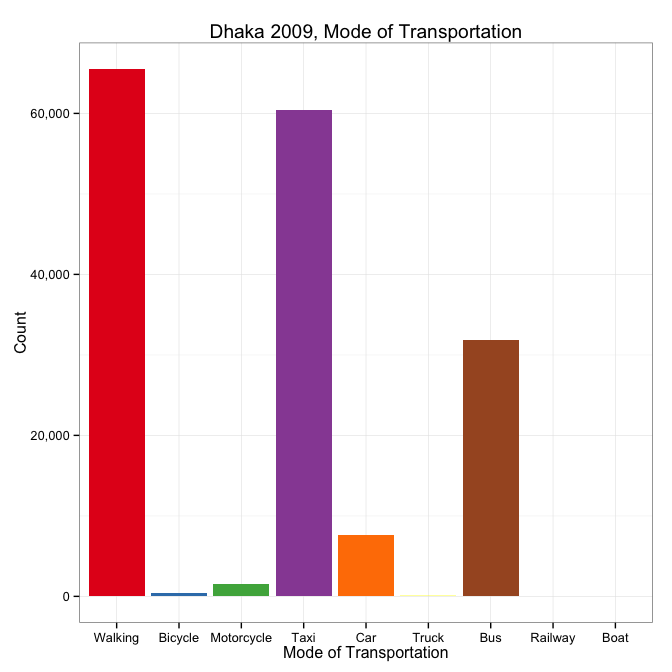

### 1.3.2 Hanoi 2004

The 34,846 people in the sample made a total of 302,813 subtrips. 59.0% of these are actually stationarity events, which reduces the true number of subtrips to 124,062. The subtrip data occupies 6.5 Mb of memory.

Data set description:

```r
describe(hni04.subtrip)
```

```
## hni04.subtrip
##
##  9  Variables      124062  Observations
## ---------------------------------------------------------------------------
## pid
##       n missing  unique
##  124062       0   42908
##
## lowest : 2     4     6     7     8
## highest: 75912 75913 75914 75915 75918
## ---------------------------------------------------------------------------
## tno
##       n missing  unique
##  124062       0      28
##
## lowest : 1  2  3  4  5 , highest: 24 25 26 27 28
## ---------------------------------------------------------------------------
## sno
##       n missing  unique
##  124062       0       4
##
## 1 (122530, 99%), 2 (1264, 1%), 3 (134, 0%), 4 (134, 0%)
## ---------------------------------------------------------------------------
## tmode
##       n missing  unique
##  124062       0      15
##
## Walking (35301, 28%), Bicycle (26091, 21%)
## Motorcycle (driver) (49217, 40%)
## Motorcycle (passenger) (7182, 6%)
## Car (driver) (599, 0%)
## Car (passenger, not taxi) (578, 0%)
## Minibus (<=25 pax) (326, 0%)
## Standard bus (>25 pax) (2983, 2%)
## Cyclo (47, 0%), Xe om (736, 1%), Taxi (187, 0%)
## Tourist bus (68, 0%), Company bus (331, 0%)
## School bus (114, 0%), Truck (302, 0%)
## ---------------------------------------------------------------------------
## tmodec
##       n missing  unique
```

[output cut: 37 more lines]

```
## highest: 2004-10-01 23:20:00 2004-10-01 23:25:00 2004-10-01 23:30:00 2004-10-01 23:40:00 2004-10-01 23:45:00
## ---------------------------------------------------------------------------
## pdate_e
##                   n             missing              unique
##              124062                   0                 873
##                Mean                 .05                 .10
## 2004-10-01 12:11:37 2004-10-01 06:35:00 2004-10-01 07:00:00
##                 .25                 .50                 .75
## 2004-10-01 07:45:00 2004-10-01 11:40:00 2004-10-01 16:50:00
##                 .90                 .95
## 2004-10-01 18:10:00 2004-10-01 19:45:00
##
## lowest : 2004-10-01 00:05:00 2004-10-01 00:15:00 2004-10-01 01:10:00 2004-10-01 01:15:00 2004-10-01 01:20:00
## highest: 2004-10-01 23:40:00 2004-10-01 23:45:00 2004-10-01 23:50:00 2004-10-01 23:55:00 2004-10-01 23:59:00
## ---------------------------------------------------------------------------
```

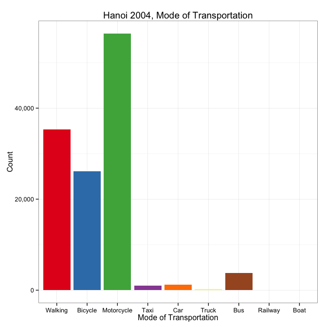

### 1.3.3 Jakarta 2002

```
## [1] TRUE
```

```
## [1] TRUE
```

```
## [1] TRUE
```

```
## [1] TRUE
```

The 36,713 people in the sample made a total of 2,101,280 subtrips. 49.6% of these are actually stationarity events, which reduces the true number of subtrips to 1,058,822.

Data set description:

```r
format(object.size(jkt02.subtrip), units = "auto")
```

```
## [1] "68.4 Mb"
```

```r
names(jkt02.subtrip)
```

```
## [1] "pid"      "tno"      "sno"      "tmode"    "tmodec"   "activity"
## [7] "dist"     "pdate_s"  "pdate_e"
```

```r
str(jkt02.subtrip)
```

```
## 'data.frame':    1058822 obs. of  9 variables:
##  $ pid     : Factor w/ 297043 levels "1","2","3","4",..: 1 1 1 1 1 1 1 2 2 3 ...
##  $ tno     : Factor w/ 33 levels "1","2","3","4",..: 2 4 6 8 10 12 14 2 4 2 ...
##  $ sno     : Factor w/ 6 levels "1","2","3","4",..: 1 1 1 1 1 1 1 1 1 1 ...
##  $ tmode   : Factor w/ 23 levels "Walking to final destination",..: 5 5 5 5 5 5 5 1 1 1 ...
##  $ tmodec  : Factor w/ 9 levels "Walking","Bicycle",..: 5 5 5 5 5 5 5 1 1 1 ...
##  $ activity: Factor w/ 7 levels "Home","Work",..: NA NA NA NA NA NA NA NA NA NA ...
##  $ dist    : num  3929 2428 2088 5709 9023 ...
##  $ pdate_s : POSIXct, format: "2002-10-01 07:30:00" "2002-10-01 09:00:00" ...
##  $ pdate_e : POSIXct, format: "2002-10-01 08:05:00" "2002-10-01 09:10:00" ...
```

```r
levels(jkt02.subtrip$tmodec)
```

```
## [1] "Walking"    "Bicycle"    "Motorcycle" "Taxi"       "Car"
## [6] "Truck"      "Bus"        "Railway"    "Boat"
```

```r
table(jkt02.subtrip$tmodec)
```

```
##
##    Walking    Bicycle Motorcycle       Taxi        Car      Truck
##     478734      17169     113412      63061      54107        636
##        Bus    Railway       Boat
##     331703          0          0
```

```r
levels(jkt02.subtrip$activity)
```

```
## [1] "Home"               "Work"               "Education"
## [4] "Shopping"           "Social, recreation" "Errand"
## [7] "Other, unknown"
```

```r
table(jkt02.subtrip$activity)
```

```
##
##               Home               Work          Education
##                  0                  0                  0
##           Shopping Social, recreation             Errand
##                  0                  0                  0
##     Other, unknown
##                  0
```

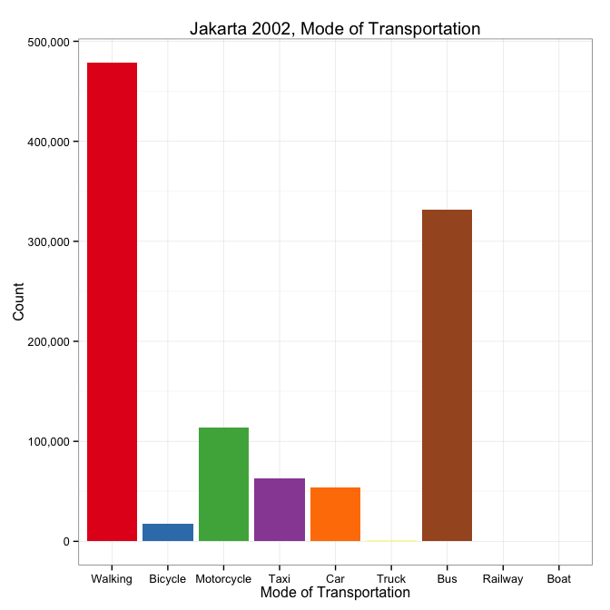

### 1.3.4 Metro Manila 1996

```
## [1] TRUE
```

```
## [1] TRUE
```

```
## [1] TRUE
```

```
## [1] TRUE
```

The 189,335 people in the sample made a total of 1,077,258 subtrips. 47.5% of these are actually stationarity events, which reduces the true number of subtrips to 565,041.

Data set description:

```r
format(object.size(mnl96.subtrip), units = "auto")
```

```
## [1] "27.4 Mb"
```

```r
names(mnl96.subtrip)
```

```
## [1] "pid"      "tno"      "sno"      "tmode"    "tmodec"   "activity"
## [7] "dist"
```

```r
str(mnl96.subtrip)
```

```
## 'data.frame':    565041 obs. of  7 variables:
##  $ pid     : Factor w/ 189335 levels "1","2","3","4",..: 1 1 3 3 3 3 3 3 4 4 ...
##  $ tno     : Factor w/ 40 levels "1","2","3","4",..: 2 4 2 2 2 4 4 4 2 4 ...
##  $ sno     : Factor w/ 9 levels "1","2","3","4",..: 1 1 1 2 3 1 2 3 1 1 ...
##  $ tmode   : Factor w/ 21 levels "Walking","Pedicab",..: 1 1 1 6 1 1 6 1 2 1 ...
##  $ tmodec  : Factor w/ 9 levels "Walking","Bicycle",..: 1 1 1 7 1 1 7 1 4 1 ...
##  $ activity: Factor w/ 7 levels "Home","Work",..: NA NA NA NA NA NA NA NA NA NA ...
##  $ dist    : num  NA NA NA NA NA NA NA NA NA NA ...
```

```r
levels(mnl96.subtrip$tmodec)
```

```
## [1] "Walking"    "Bicycle"    "Motorcycle" "Taxi"       "Car"
## [6] "Truck"      "Bus"        "Railway"    "Boat"
```

```r
table(mnl96.subtrip$tmodec)
```

```
##
##    Walking    Bicycle Motorcycle       Taxi        Car      Truck
##     232123       2292      89554      19110      26347       1308
##        Bus    Railway       Boat
##     193627          0        680
```

```r
levels(mnl96.subtrip$activity)
```

```
## [1] "Home"               "Work"               "Education"
## [4] "Shopping"           "Social, recreation" "Errand"
## [7] "Other, unknown"
```

```r
table(mnl96.subtrip$activity)
```

```
##
##               Home               Work          Education
##                  0                  0                  0
##           Shopping Social, recreation             Errand
##                  0                  0                  0
##     Other, unknown
##                  0
```

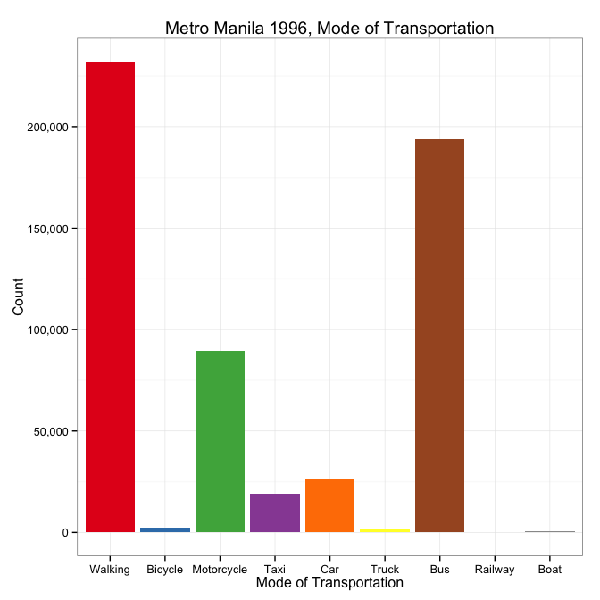

### 1.3.5 Comparison Across Cities

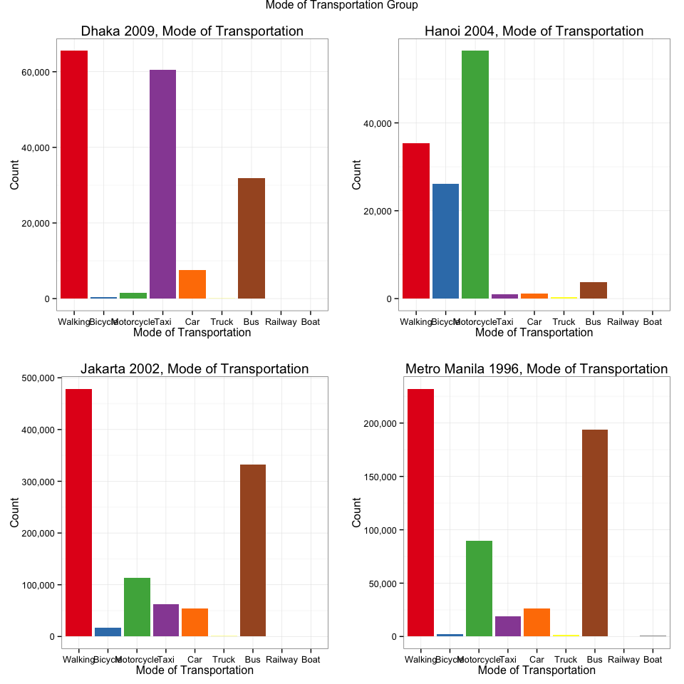

## 1.4 Commuting Behavior

This section covers the analysis of the commuting behavior in all four cities both in the morning (0:00 - 11:59) and in the evening (12:00 - 23:59) regarding distance, duration, and multi-modality.

### 1.4.1 Dhaka 2009

Data set description:

```r
dhk09CommBehavSexNoon <- ddply(dhk09.commbehav, c("sex", "noon"), summarize,
                               mean_dist = mean(dist),
                               mean_duration = mean(duration),
                               subtrips = mean(subtrips))
dhk09CommBehavAgeNoon <- ddply(dhk09.commbehav, c("age", "noon"), summarize,
                               mean_dist = mean(dist),
                               mean_duration = mean(duration),
                               subtrips = mean(subtrips))
dhk09CommBehavOccupCNoon <- ddply(dhk09.commbehav, c("occupc", "noon"), summarize,
                                  mean_dist = mean(dist),
                                  mean_duration = mean(duration),
                                  subtrips = mean(subtrips))
print(xtable(dhk09CommBehavSexNoon, type = "html"))
```

[output not shown]

```r
print(xtable(dhk09CommBehavAgeNoon, type = "html"))
```

[output not shown]

```r
print(xtable(dhk09CommBehavOccupCNoon, type = "html"))
```

[output not shown]

[figure not shown]

### 1.4.2 Hanoi 2004

Data set description:

```r
print(xtable(ddply(hni04.commbehav, c("sex", "noon"), summarize,
                   mean_dist = mean(dist),
                   mean_duration = mean(duration),
                   subtrips = mean(subtrips))),
      type = "html")
```

```
## <!-- html table generated in R 3.1.0 by xtable 1.7-3 package -->
## <!-- Thu Jul 17 19:11:02 2014 -->
## <TABLE border=1>
## <TR> <TH>  </TH> <TH> sex </TH> <TH> noon </TH> <TH> mean_dist </TH> <TH> mean_duration </TH> <TH> subtrips </TH>  </TR>
##   <TR> <TD align="right"> 1 </TD> <TD> Male </TD> <TD> noon </TD> <TD align="right"> 4607.51 </TD> <TD align="right"> 19.54 </TD> <TD align="right"> 1.02 </TD> </TR>
##   <TR> <TD align="right"> 2 </TD> <TD> Male </TD> <TD> afternoon </TD> <TD align="right"> 4655.49 </TD> <TD align="right"> 20.67 </TD> <TD align="right"> 1.02 </TD> </TR>
##   <TR> <TD align="right"> 3 </TD> <TD> Female </TD> <TD> noon </TD> <TD align="right"> 4062.93 </TD> <TD align="right"> 19.18 </TD> <TD align="right"> 1.02 </TD> </TR>
##   <TR> <TD align="right"> 4 </TD> <TD> Female </TD> <TD> afternoon </TD> <TD align="right"> 4069.47 </TD> <TD align="right"> 20.11 </TD> <TD align="right"> 1.02 </TD> </TR>
##    </TABLE>
```

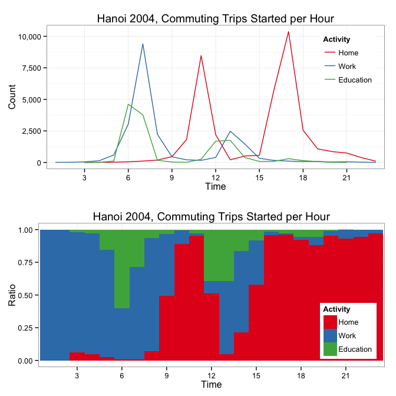

### 1.4.3 Jakarta 2002

Data set description:

```r
print(xtable(ddply(jkt02.commbehav, c("sex", "noon"), summarize,
                   mean_dist = mean(dist),
                   mean_duration = mean(duration),
                   subtrips = mean(subtrips))),
      type = "html")
```

```
## <!-- html table generated in R 3.1.0 by xtable 1.7-3 package -->
## <!-- Thu Jul 17 19:12:26 2014 -->
## <TABLE border=1>
## <TR> <TH>  </TH> <TH> sex </TH> <TH> noon </TH> <TH> mean_dist </TH> <TH> mean_duration </TH> <TH> subtrips </TH>  </TR>
##   <TR> <TD align="right"> 1 </TD> <TD> Male </TD> <TD> noon </TD> <TD align="right"> 10032.60 </TD> <TD align="right"> 35.33 </TD> <TD align="right"> 1.49 </TD> </TR>
##   <TR> <TD align="right"> 2 </TD> <TD> Male </TD> <TD> afternoon </TD> <TD align="right"> 22473.76 </TD> <TD align="right"> 38.37 </TD> <TD align="right"> 1.52 </TD> </TR>
##   <TR> <TD align="right"> 3 </TD> <TD> Female </TD> <TD> noon </TD> <TD align="right"> 9517.82 </TD> <TD align="right"> 32.23 </TD> <TD align="right"> 1.52 </TD> </TR>
##   <TR> <TD align="right"> 4 </TD> <TD> Female </TD> <TD> afternoon </TD> <TD align="right"> 22091.35 </TD> <TD align="right"> 35.92 </TD> <TD align="right"> 1.61 </TD> </TR>
##    </TABLE>
```

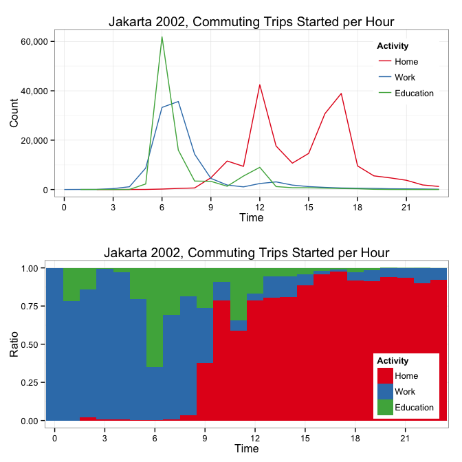

### 1.4.4 Metro Manila 1996

Data set description:

```r
# print(xtable(ddply(mnl96.commbehav, c("sex", "noon"), summarize,
#                    mean_dist = mean(dist),
#                    mean_duration = mean(duration),
#                    subtrips = mean(subtrips))),
#       type = "html")
```

[figure not shown]

### 1.4.5 Comparison Across Cities

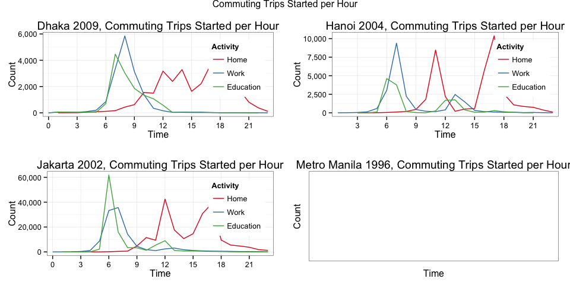

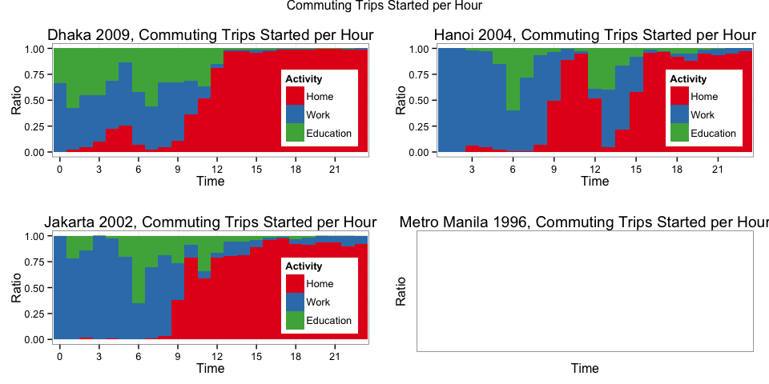

## 1.5 Spatio-Temporal Distribution of People

### 1.5.1 Dhaka 2009

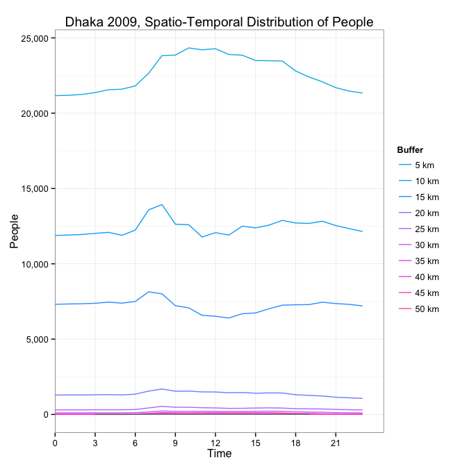

### 1.5.2 Hanoi 2004

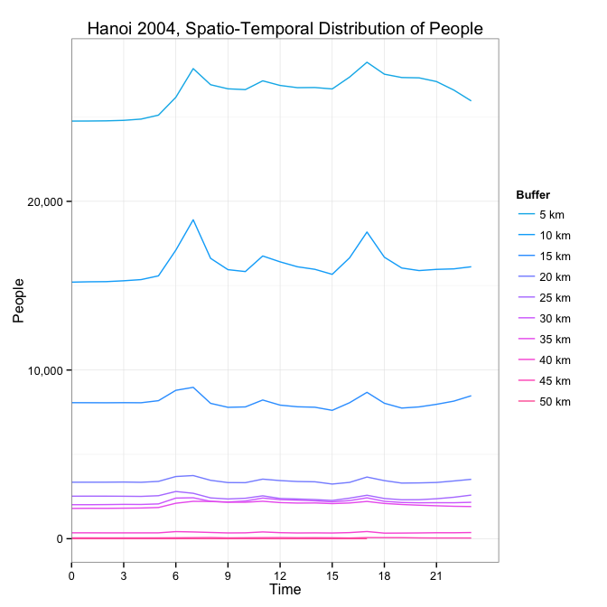

### 1.5.5 Comparison Across Cities

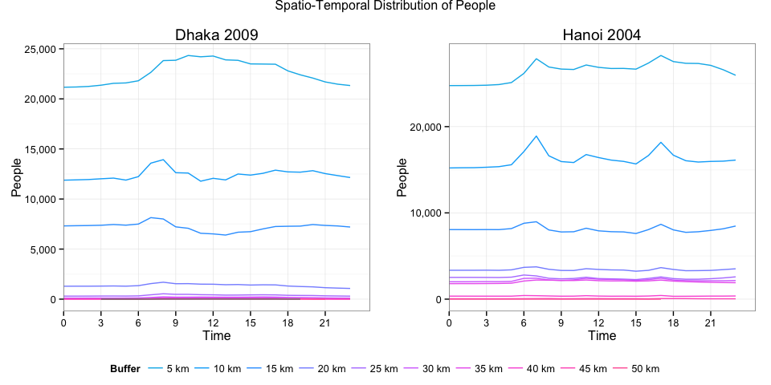

## 1.7 Final Steps

It’s always a good idea to clean up after you’re done…

```
## [1] TRUE
```

```
## [1] TRUE
```